# FinalProject

Gaye Çolakoğlu

2022-06-06

The scope of this project is the analyze students’ performance in exams from the datasets generated by the Royce Kimmons(http://roycekimmons.com/tools/generated_data/exams).

In this project, we will try to analyze and understand the influence of the parents’ background, test preparation, etc on student’s performance

The difference between score in none and completed test prepration groups try to clarify. The most higher score will be handled and try to figure out the main reasons for this scores is higher.

The score differences between the parental education try to be handled, and the question of ‘Is there a specific difference in scores between the parental education’ tries to be answered.

In the last part, the project tries to find if there is an association between having lunch and math scores.

**Importing Required Libraries**

```r
Packages <- c( "scatterplot3d", "plot3D","plyr",  "magrittr", "data.table")
libs <- suppressWarnings(suppressMessages(lapply(Packages, library, character.only = TRUE)))

#install.packages('Rmisc')
library(Rmisc)
library(corrplot)
library(Hmisc)
library(reshape2)
library(tidyverse)
library(gridExtra)
library(dplyr)      # data manipulation
library(ggplot2)    # data visualization
library(ggpubr)     # normality test
library(naniar)     # check for missing values
```

# 1. Data

```r
student_df <- read.csv("C:\\Users\\Gaye\\OneDrive\\Masaüstü\\dersler\\thirdYear\\secondSemester\\statistcalComputing\\StudentsPerformance.csv")
#View(student_df)
head(student_df, 10)
```

```
##    gender race.ethnicity parental.level.of.education        lunch
## 1  female        group B           bachelor's degree     standard
## 2  female        group C                some college     standard
## 3  female        group B             master's degree     standard
## 4    male        group A          associate's degree free/reduced
## 5    male        group C                some college     standard
## 6  female        group B          associate's degree     standard
## 7  female        group B                some college     standard
## 8    male        group B                some college free/reduced
## 9    male        group D                 high school free/reduced
## 10 female        group B                 high school free/reduced
##    test.preparation.course math.score reading.score writing.score
## 1                     none         72            72            74
## 2                completed         69            90            88
## 3                     none         90            95            93
## 4                     none         47            57            44
## 5                     none         76            78            75
## 6                     none         71            83            78
## 7                completed         88            95            92
## 8                     none         40            43            39
## 9                completed         64            64            67
## 10                    none         38            60            50
```

**Explanation of the Columns**

- gender: Information about student gender
- race.ethnicity: Information about race/ethnicity
- parental.level.of.education: Information about parental level of education
- lunch: Information about student’s lunch
- test.preparation.course: Information about student’s test preparation course
- math.score: Information about student’s math score
- reading.score: Information about student’s reading score
- writing.score: Information about student’s writing score

Let’s run str() to get information about types of features.

```r
str(student_df)
```

```
## 'data.frame':    1000 obs. of  8 variables:
##  $ gender                     : chr  "female" "female" "female" "male" ...
##  $ race.ethnicity             : chr  "group B" "group C" "group B" "group A" ...
##  $ parental.level.of.education: chr  "bachelor's degree" "some college" "master's degree" "associate's degree" ...
##  $ lunch                      : chr  "standard" "standard" "standard" "free/reduced" ...
##  $ test.preparation.course    : chr  "none" "completed" "none" "none" ...
##  $ math.score                 : int  72 69 90 47 76 71 88 40 64 38 ...
##  $ reading.score              : int  72 90 95 57 78 83 95 43 64 60 ...
##  $ writing.score              : int  74 88 93 44 75 78 92 39 67 50 ...
```

From the above result we can see that our data contains both categorical and quantitative variables.

Let’s look in a more visualize way

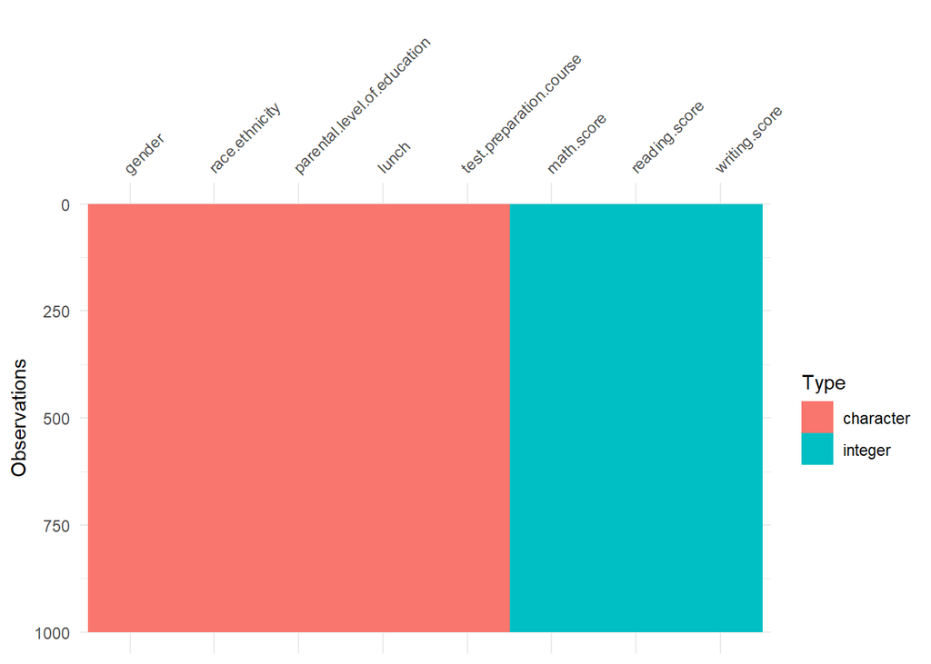

```r
library(visdat)
vis_dat(student_df)
```

gender, race.ethinicity, parental.level.of.education, lunch, test.preparation.course columns have character data and math.score, reading.score and writing.score columns have integer data.

# 2. Exploratory and Descriptive Data Analaysis

**Displaying statistical summary of the data**

```r
summary(student_df)
```

```
##     gender          race.ethnicity     parental.level.of.education
##  Length:1000        Length:1000        Length:1000
##  Class :character   Class :character   Class :character
##  Mode  :character   Mode  :character   Mode  :character
##
##
##
##     lunch           test.preparation.course   math.score     reading.score
##  Length:1000        Length:1000             Min.   :  0.00   Min.   : 17.00
##  Class :character   Class :character        1st Qu.: 57.00   1st Qu.: 59.00
##  Mode  :character   Mode  :character        Median : 66.00   Median : 70.00
##                                             Mean   : 66.09   Mean   : 69.17
##                                             3rd Qu.: 77.00   3rd Qu.: 79.00
##                                             Max.   :100.00   Max.   :100.00
##  writing.score
##  Min.   : 10.00
##  1st Qu.: 57.75
##  Median : 69.00
##  Mean   : 68.05
##  3rd Qu.: 79.00
##  Max.   :100.00
```

**Analysis of the output**

*Mean*

- The average math.score is 66.09.
- The average reading.score is 69.17.
- The average writing.score is 68.05.
- We can also assume that students are more successful in reading than in math or writing.

*Median*

- Most of the observations are the same as mean value observation.
- The difference in mean and median value is due to outliers. We can also observe this difference in categorical variables.

**Checking For Missing Values**

```r
miss_var_summary(student_df)
```

```
## # A tibble: 8 x 3
##   variable                    n_miss pct_miss
##   <chr>                        <int>    <dbl>
## 1 gender                           0        0
## 2 race.ethnicity                   0        0
## 3 parental.level.of.education      0        0
## 4 lunch                            0        0
## 5 test.preparation.course          0        0
## 6 math.score                       0        0
## 7 reading.score                    0        0
## 8 writing.score                    0        0
```

NA with more visualize way

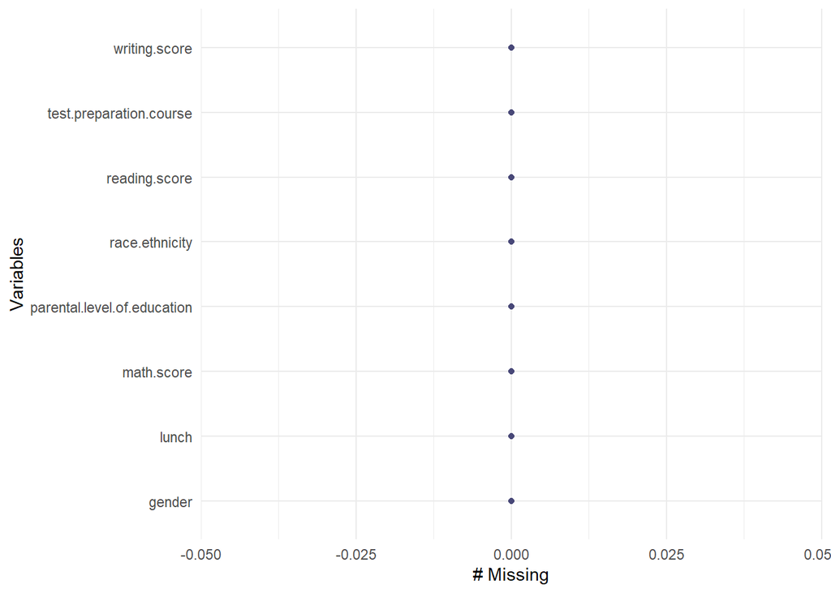

```r
gg_miss_var(student_df)
```

**Finding Uniques in each column**

```r
for (i in seq(1,ncol(student_df)-3,1)){
  print(unique(student_df[i]))
}
```

```
##   gender
## 1 female
## 4   male
##    race.ethnicity
## 1         group B
## 2         group C
## 4         group A
## 9         group D
## 33        group E
##    parental.level.of.education
## 1            bachelor's degree
## 2                 some college
## 3              master's degree
## 4           associate's degree
## 9                  high school
## 16            some high school
##          lunch
## 1     standard
## 4 free/reduced
##   test.preparation.course
## 1                    none
## 2               completed
```

**Data preparation**

Renaming the columns for the ease of use

```r
colnames(student_df)[2] <- "race_ethnicity"
colnames(student_df)[3] <- "parental_education"
colnames(student_df)[5] <- "test_prep"
colnames(student_df)[6] <- "math_score"
colnames(student_df)[7] <- "reading_score"
colnames(student_df)[8] <- "writing_score"
str(student_df)
```

```
## 'data.frame':    1000 obs. of  8 variables:
##  $ gender            : chr  "female" "female" "female" "male" ...
##  $ race_ethnicity    : chr  "group B" "group C" "group B" "group A" ...
##  $ parental_education: chr  "bachelor's degree" "some college" "master's degree" "associate's degree" ...
##  $ lunch             : chr  "standard" "standard" "standard" "free/reduced" ...
##  $ test_prep         : chr  "none" "completed" "none" "none" ...
##  $ math_score        : int  72 69 90 47 76 71 88 40 64 38 ...
##  $ reading_score     : int  72 90 95 57 78 83 95 43 64 60 ...
##  $ writing_score     : int  74 88 93 44 75 78 92 39 67 50 ...
```

# 3. Data Visualization

First of all, let’s look at the student population.

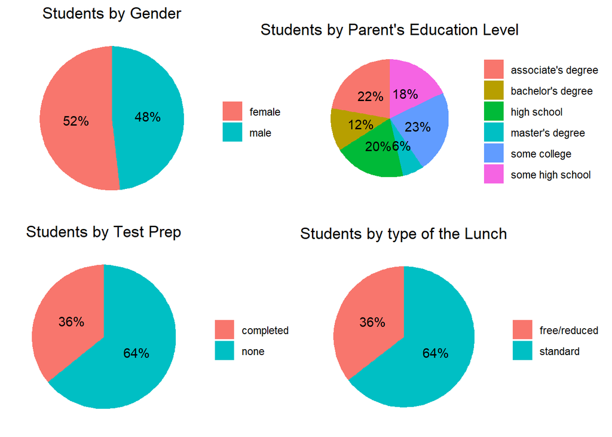

```r
# convert df to data.table
dff <- as.data.table(student_df)

piePlotter <- function(data,y,fill, title){
  pie <- ggplot(data, aes(x="", y=y, fill= fill)) + geom_bar(stat="identity", width=2) + coord_polar("y", start=0) +  geom_text(aes(label = paste0(round(y/10), "%")), position =  position_stack(vjust = 0.5)) + labs(x = NULL, y = NULL, fill = NULL, title = title) + theme_classic() + theme(axis.line = element_blank(), axis.text = element_blank(), axis.ticks = element_blank(), plot.title = element_text(hjust = 0.5, color = "#000000"));
}

gernderSplit<-dff[,.N,by=gender]
colnames(gernderSplit)<-c("Gender","Count")

parentEduSplit<-dff[,.N,by=parental_education]
colnames(parentEduSplit)<-c("EducationLevel","Count")
parentEduSplit <- parentEduSplit[order(Count),]

testSplit<-dff[,.N,by=test_prep]
colnames(testSplit)<-c("Test","Count")

lunchSplit<-dff[,.N,by=lunch]
colnames(lunchSplit)<-c("Lunch","Count")

byGnderPlot<-piePlotter(gernderSplit, gernderSplit$Count,gernderSplit$Gender, "Students by Gender")
byParentEduLevel<-piePlotter(parentEduSplit, parentEduSplit$Count,parentEduSplit$EducationLevel, "Students by Parent's Education Level")
byTest<-piePlotter(testSplit, testSplit$Count,testSplit$Test, "Students by Test Prep")
byLunch<-piePlotter(lunchSplit, lunchSplit$Count,lunchSplit$Lunch, "Students by type of the Lunch")


grid.arrange(byGnderPlot, byParentEduLevel,byTest, byLunch, ncol=2)
```

Let’s use a more fun plot for race

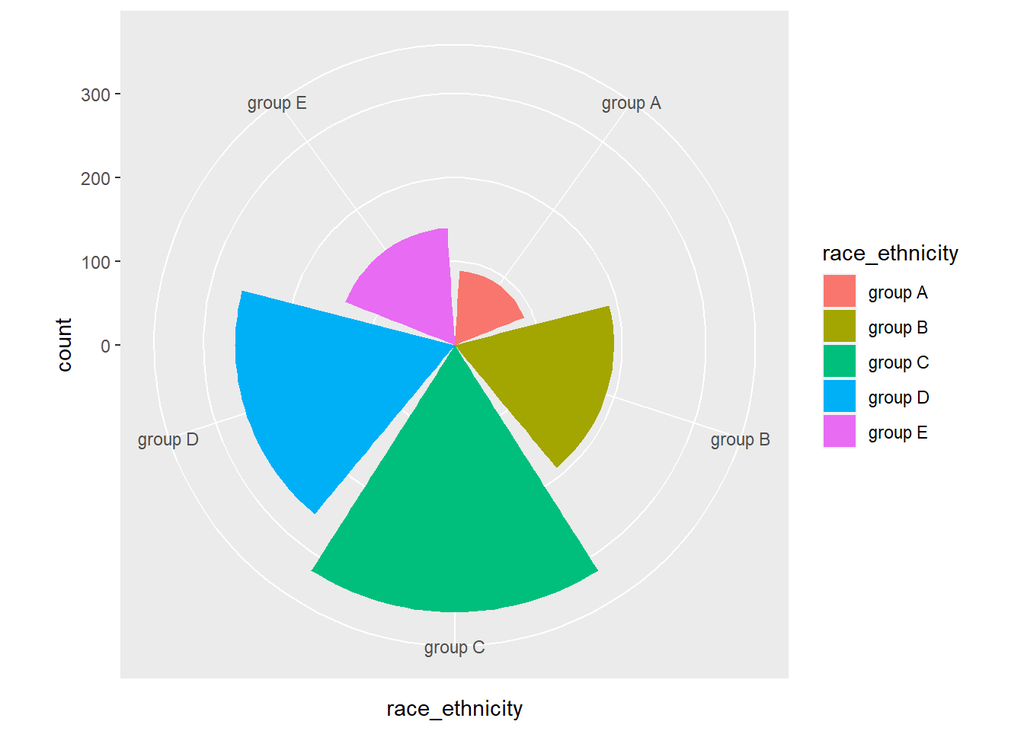

```r
pie <- ggplot(student_df,aes(x=race_ethnicity, fill = race_ethnicity))+
  geom_bar()+
  theme(axis.line = element_blank(),
        plot.title = element_text(hjust=0.1))

pie + coord_polar(theta = "x",start=0)
```

What we find:

- There are more female students in the population than male students
- Majority of parents of the students have studied up to college level. 40% of parents have a degree.
- Majority of the students belong to the race group C. Second largest student community is from race group D. Group A is the minor race group of the student population.
- Approximately 2/3 of the students take standard lunch.

Let’s try to dig more into students background using parent education level, lunch category and race.

**Scores By gender:**

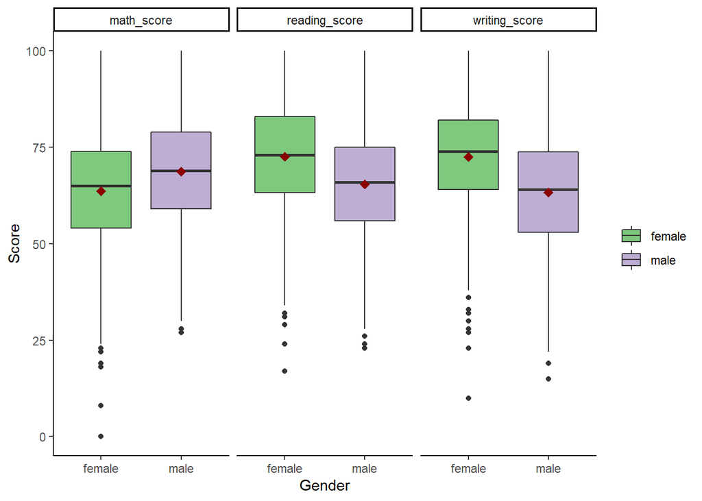

```r
Data_gather <- student_df %>%
  mutate(StudentID = row_number()) %>%
  gather(key = "subject", value = "score", math_score:writing_score)

plot6 <- ggplot(data=Data_gather, aes(x=Data_gather$gender, y=Data_gather$score,
                             fill=Data_gather$gender)) +
  geom_boxplot() +
  stat_summary(fun.y=mean, colour="darkred", geom="point",
               shape=18, size=3,show_guide = FALSE) +
  facet_grid(. ~ subject ) +
  theme_bw() +
  theme_classic() +
  theme(legend.title = element_blank()) +
  xlab("Gender") +
  ylab("Score") +
  scale_fill_brewer(type = "qual", palette = 1, direction = 1,
  aesthetics = "fill")
plot6
```

*AVERAGE SCORE*

- Averagely speaking, female students are doing a better job in reading and writing, while male students have a higher score in math. The difference is the biggest with writing subject.

*STANDARD DEVIATION*

- In all three subject, female students have scores that are distributed more loosely.

*SCORE DISTRIBUTION*

- Female students: For math subject, the score range 60-69 has the most number of students. For reading and writing, the score range 70-79 has the most number of students.
- Male students: For math subject, the distribution of scores is slightly right shifted compared to females’ score distribution. But the most number of male students still have scores located in range 60-69. For reading subject, the distribution of scores is left shifted compared to females’ score distribution. For writing subject, the shift is even more obvious. But for both subjects, the most number of male students have scores located in range 60-69.

**Scores by race/ethnicity: Average scores are highest in the group E.**

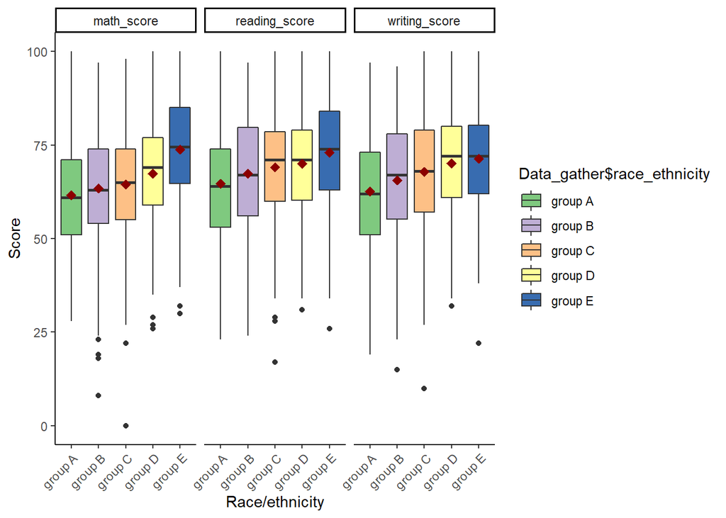

```r
plot5 <- ggplot(data=Data_gather, aes(x=Data_gather$race_ethnicity, y=Data_gather$score,
                             fill=Data_gather$race_ethnicity)) +
  geom_boxplot() +
    theme(
    text = element_text(family = "Tahoma"),
    axis.text.x = element_blank(),
    legend.title = element_blank()
    ) +

  stat_summary(fun.y=mean, colour="darkred", geom="point",
               shape=18, size=3,show_guide = FALSE) +
  facet_grid(. ~ subject ) +
  theme_bw() +
  theme_classic() +
  scale_fill_brewer(type = "qual", palette = 1, direction = 1,
  aesthetics = "fill") +
  xlab("Race/ethnicity") +
  ylab("Score")+
  theme(axis.text.x= element_text(angle =45, hjust=1))
plot5
```

Result If we can say that the the people who scores higher than 80 will be more effective in society. Than it could be said that, group E is the leading one and group A is the last one. However group C seems to have highest population at all. However, if we take the proportion of passing population and general population, we can see that group E is the most successful ethnic group.

**Scores by Lunch**

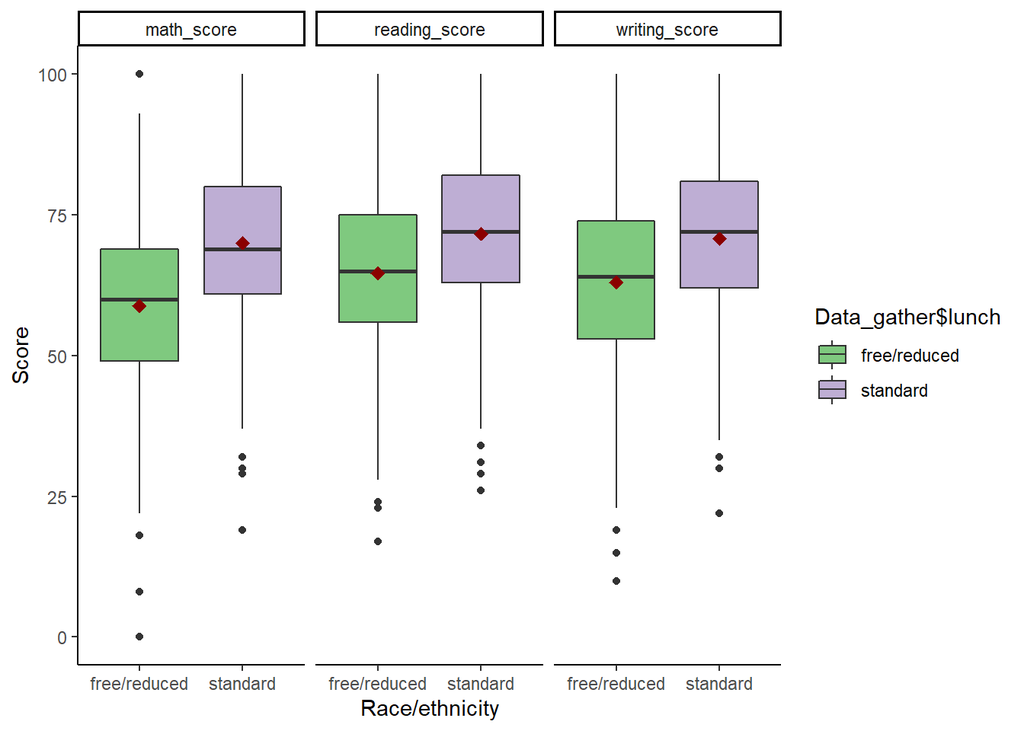

```r
plot5 <- ggplot(data=Data_gather, aes(x=Data_gather$lunch, y=Data_gather$score,
                             fill=Data_gather$lunch)) +
  geom_boxplot() +
    theme(
    text = element_text(family = "Tahoma"),
    axis.text.x = element_blank(),
    legend.title = element_blank()
    ) +

  stat_summary(fun.y=mean, colour="darkred", geom="point",
               shape=18, size=3,show_guide = FALSE) +
  facet_grid(. ~ subject ) +
  theme_bw() +
  theme_classic() +
  scale_fill_brewer(type = "qual", palette = 1, direction = 1,
  aesthetics = "fill") +
  xlab("Race/ethnicity") +
  ylab("Score")
plot5
```

Result As shown in the table, students with standard lunch have better performance in the tests.

**Scores by Parental Education**

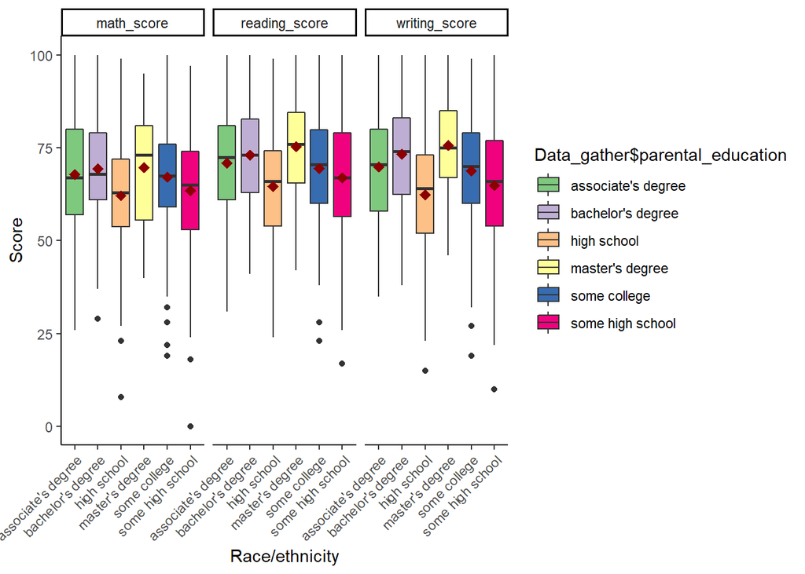

```r
plot5 <- ggplot(data=Data_gather, aes(x=Data_gather$parental_education, y=Data_gather$score,
                             fill=Data_gather$parental_education)) +
  geom_boxplot() +
    theme(
    text = element_text(family = "Tahoma"),
    axis.text.x = element_blank(),
    legend.title = element_blank()
    ) +

  stat_summary(fun.y=mean, colour="darkred", geom="point",
               shape=18, size=3,show_guide = FALSE) +
  facet_grid(. ~ subject ) +
  theme_bw() +
  theme_classic() +
  scale_fill_brewer(type = "qual", palette = 1, direction = 1,
  aesthetics = "fill") +
  xlab("Race/ethnicity") +
  ylab("Score")+
  theme(axis.text.x= element_text(angle =45, hjust=1))
plot5
```

**Let’s look into parental education effect on students success more deeply**

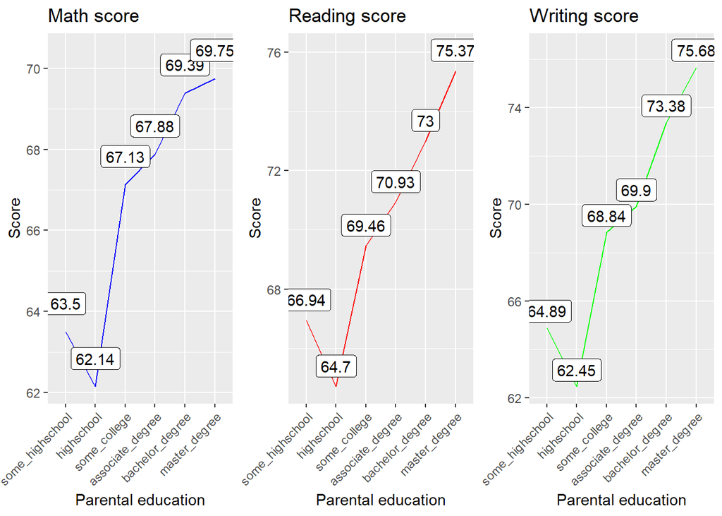

```r
#Math score
plot_df <- data.frame(parental_education = c("some_highschool","highschool","some_college","associate_degree","bachelor_degree","master_degree"),
               math = c(63.50,62.14,67.13,67.88,69.39,69.75),
               reading = c(66.94,64.70,69.46,70.93,73.00,75.37),
               writing  = c(64.89,62.45,68.84,69.90,73.38,75.68))


p1 <- ggplot(plot_df,aes(x=factor(parental_education,level=c("some_highschool","highschool","some_college","associate_degree","bachelor_degree","master_degree")),y=math,group=1))+
  geom_line(color="blue")+
  geom_label(aes(label = math, size = NULL,color=NULL), nudge_y = 0.7)+
  ggtitle("Math score")+
  xlab("Parental education")+
  ylab("Score")+
  theme(axis.text.x= element_text(angle =45, hjust=1))

#Reading score
p2 <- ggplot(plot_df,aes(x=factor(parental_education,level=c("some_highschool","highschool","some_college","associate_degree","bachelor_degree","master_degree")),y=reading,group=1))+
  geom_line(color="red")+
  geom_label(aes(label = reading, size = NULL,color=NULL), nudge_y = 0.7)+
  ggtitle("Reading score")+
  xlab("Parental education")+
  ylab("Score")+
  theme(axis.text.x= element_text(angle =45, hjust=1))

#writing score
p3 <- ggplot(plot_df,aes(x=factor(parental_education,level=c("some_highschool","highschool","some_college","associate_degree","bachelor_degree","master_degree")),y=writing,group=1))+
  geom_line(color="green")+
  geom_label(aes(label = writing, size = NULL,color=NULL), nudge_y = 0.7)+
  ggtitle("Writing score")+
  xlab("Parental education")+
  ylab("Score")+
  theme(axis.text.x= element_text(angle =45, hjust=1))

Rmisc::multiplot(p1,p2,p3, cols= 3)
```

**Scores by Test Preparation**

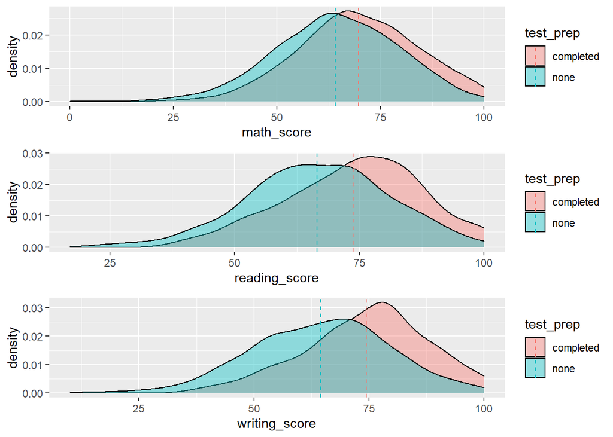

```r
library(plyr)
mu <- ddply(student_df, "test_prep", summarise, grp.mean=mean(math_score))

# Use semi-transparent fill and Add mean lines
p<-ggplot(student_df, aes(x=math_score, fill=test_prep)) +
  geom_density(alpha=0.4)+
  geom_vline(data=mu, aes(xintercept=grp.mean, color=test_prep),
             linetype="dashed")

mu <- ddply(student_df, "test_prep", summarise, grp.mean=mean(reading_score))

# Use semi-transparent fill and Add mean lines
p1<-ggplot(student_df, aes(x=reading_score, fill=test_prep)) +
  geom_density(alpha=0.4)+
  geom_vline(data=mu, aes(xintercept=grp.mean, color=test_prep),
             linetype="dashed")

mu <- ddply(student_df, "test_prep", summarise, grp.mean=mean(writing_score))

# Use semi-transparent fill and Add mean lines
p2<-ggplot(student_df, aes(x=writing_score, fill=test_prep)) +
  geom_density(alpha=0.4)+
  geom_vline(data=mu, aes(xintercept=grp.mean, color=test_prep),
             linetype="dashed")

Rmisc::multiplot(p,p1,p2, cols= 1)
```

It is clearly seen that less than half students chose and completed preparation course. But students who completed the course behave better in the tests of all three subjects, which implies the course is effective.

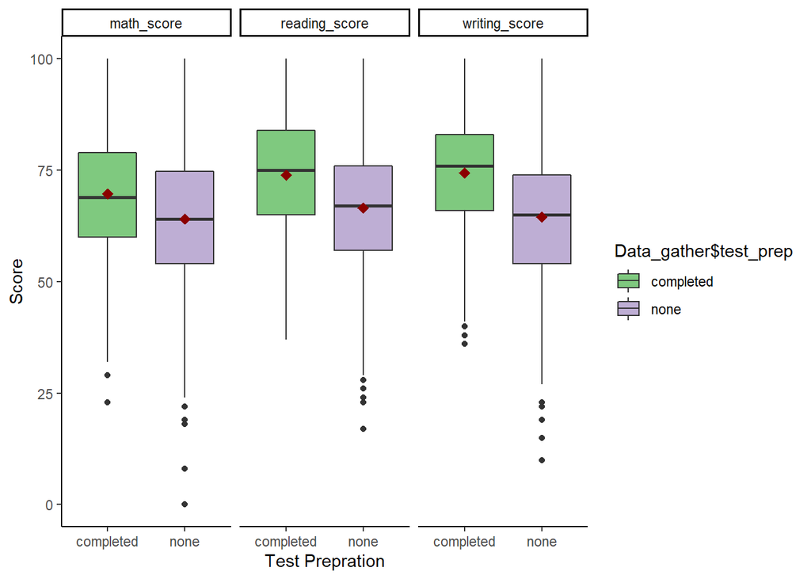

```r
plot5 <- ggplot(data=Data_gather, aes(x=Data_gather$test_prep, y=Data_gather$score,
                             fill=Data_gather$test_prep)) +
  geom_boxplot() +
    theme(
    text = element_text(family = "Tahoma"),
    axis.text.x = element_blank(),
    legend.title = element_blank()
    ) +

  stat_summary(fun.y=mean, colour="darkred", geom="point",
               shape=18, size=3,show_guide = FALSE) +
  facet_grid(. ~ subject ) +
  theme_bw() +
  theme_classic() +
  scale_fill_brewer(type = "qual", palette = 1, direction = 1,
  aesthetics = "fill") +
  xlab("Test Prepration") +
  ylab("Score")
plot5
```

Result Students who have completed test pre-course get higher scores on average in every subject, and they have scores with smaller standard deviation too.

The most obvious influence should be whether or not the student completed the test prep course.

# 4. Central Limit Theorem

```r
score <- Data_gather$score
#Calculate the population mean
mean(Data_gather$score)
```

```
## [1] 67.77067
```

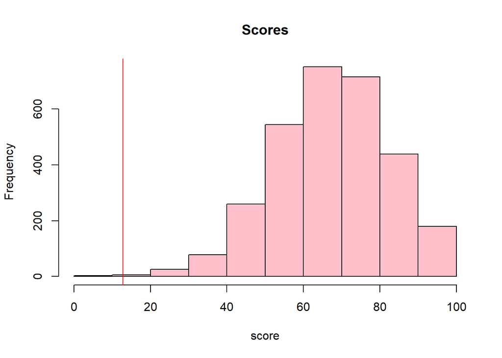

```r
#Plot all the observations in the data
hist(Data_gather$score,col = "pink",main = "Scores",xlab = "score")
abline(v=12.8,col="red",lty=1)
```

In our example, we will draw sufficient samples of size 10, calculate their means, and plot them in R. I know that the minimum sample size taken should be 30 but let’s just see what happens when we draw 10:

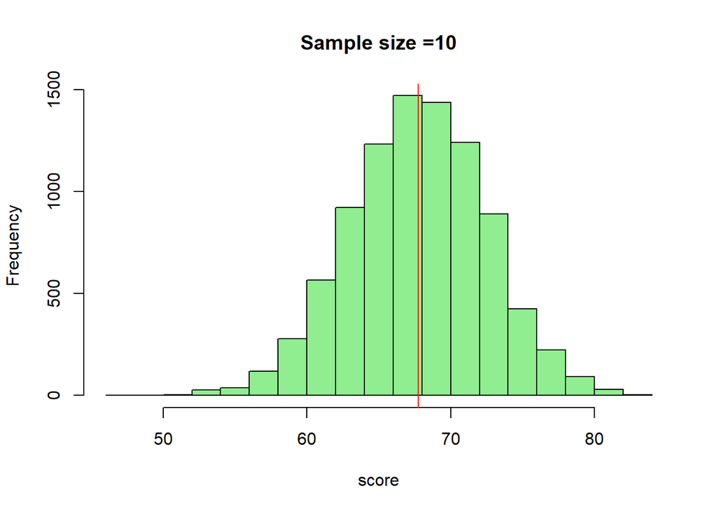

```r
#We will take sample size=10, samples=9000
#Calculate the arithmetice mean and plot the mean of sample 9000 times

s10<-c()
n=9000
for (i in 1:n) {
s10[i] = mean(sample(Data_gather$score,10, replace = TRUE))}
hist(s10, col ="lightgreen", main="Sample size =10",xlab = "score")
abline(v = mean(s10), col = "Red")
abline(v = 12.8, col = "blue")
```

Now, we know that we’ll get a very nice bell-shaped curve as the sample sizes increase. Let us now increase our sample size and see what we get:

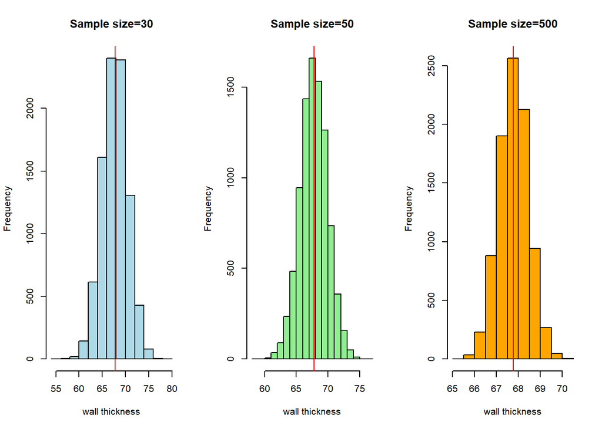

```r
#We will take sample size=30, 50 & 500 samples=9000
#Calculate the arithmetice mean and plot the mean of sample 9000 times

s30 <- c()
s50 <- c()
s500 <- c()
n =9000
for ( i in 1:n){
s30[i] = mean(sample(Data_gather$score,30, replace = TRUE))
s50[i] = mean(sample(Data_gather$score,50, replace = TRUE))
s500[i] = mean(sample(Data_gather$score,500, replace = TRUE))
}
par(mfrow=c(1,3))
hist(s30, col ="lightblue",main="Sample size=30",xlab ="wall thickness")
abline(v = mean(s30), col = "red")

hist(s50, col ="lightgreen", main="Sample size=50",xlab ="wall thickness")
abline(v = mean(s50), col = "red")

hist(s500, col ="orange",main="Sample size=500",xlab ="wall thickness")
abline(v = mean(s500), col = "red")
```

Here, we get a good bell-shaped curve and the sampling distribution approaches normal distribution as the sample sizes increase. Therefore, we can consider the sampling distributions as normal.

# 5. Confidence Intervals

Let’s see the boxplot of scores and test_prep again

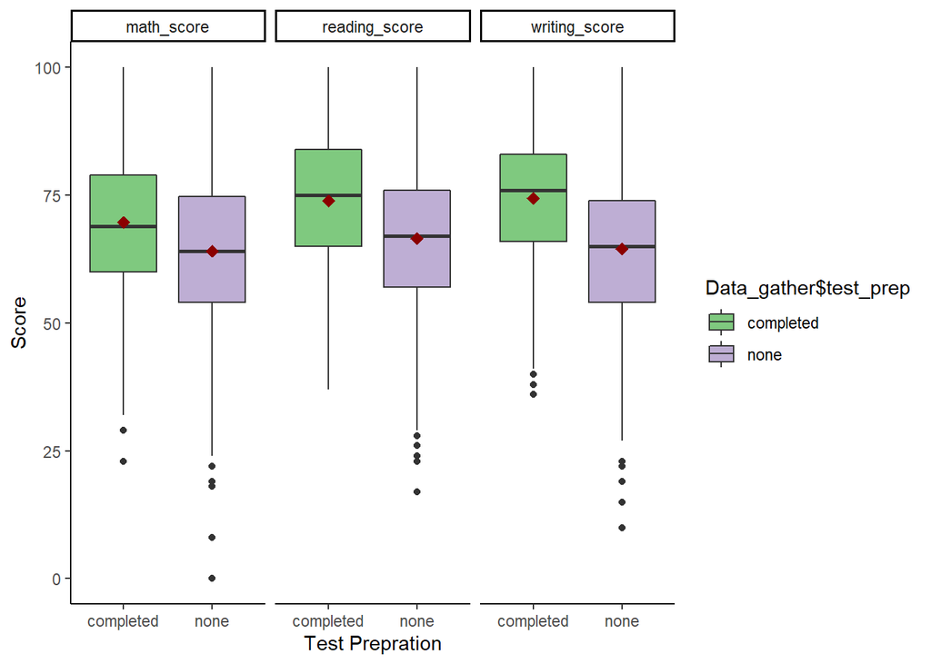

```r
plot5 <- ggplot(data=Data_gather, aes(x=Data_gather$test_prep, y=Data_gather$score,
                             fill=Data_gather$test_prep)) +
  geom_boxplot() +
    theme(
    text = element_text(family = "Tahoma"),
    axis.text.x = element_blank(),
    legend.title = element_blank()
    ) +

  stat_summary(fun.y=mean, colour="darkred", geom="point",
               shape=18, size=3,show_guide = FALSE) +
  facet_grid(. ~ subject ) +
  theme_bw() +
  theme_classic() +
  scale_fill_brewer(type = "qual", palette = 1, direction = 1,
  aesthetics = "fill") +
  xlab("Test Prepration") +
  ylab("Score")
plot5
```

This plot suggests that completing the test_prep is associated with higher score.

How can we assess whether this difference is statistically significant?

Let’s compute a summary table

```r
aggregate(Data_gather$score ~ Data_gather$test_prep,
          data = Data_gather,
          FUN = function(x) {c(mean = mean(x), sd = sd(x))})
```

```
##   Data_gather$test_prep Data_gather$score.mean Data_gather$score.sd
## 1             completed               72.66946             13.97500
## 2                  none               65.03894             14.91932
```

```r
mean(Data_gather$score)
```

```
## [1] 67.77067
```

```r
sd(Data_gather$score)
```

```
## [1] 15.03782
```

We assume that we don’t have an information about the population varience and we’ll use the t-score for calculating Confidence Intervals

Let’s take the none and completed one by one and compare their Confidence Intervals

```r
#subset the none and completed
none.vs.completed = subset(Data_gather, subset = Data_gather$test_prep == "none" | Data_gather$test_prep == "completed" )
summary(none.vs.completed)
```

```
##     gender          race_ethnicity     parental_education    lunch
##  Length:3000        Length:3000        Length:3000        Length:3000
##  Class :character   Class :character   Class :character   Class :character
##  Mode  :character   Mode  :character   Mode  :character   Mode  :character
##
##
##
##   test_prep           StudentID        subject              score
##  Length:3000        Min.   :   1.0   Length:3000        Min.   :  0.00
##  Class :character   1st Qu.: 250.8   Class :character   1st Qu.: 58.00
##  Mode  :character   Median : 500.5   Mode  :character   Median : 68.00
##                     Mean   : 500.5                      Mean   : 67.77
##                     3rd Qu.: 750.2                      3rd Qu.: 78.00
##                     Max.   :1000.0                      Max.   :100.00
```

```r
none = subset(none.vs.completed, subset = none.vs.completed$test_prep == "none")
completed = subset(none.vs.completed, subset = none.vs.completed$test_prep == "completed")
```

```r
#Confidence Interval of none
none.CI <- t.test(none$score)$conf.int
none.CI
```

```
## [1] 64.37222 65.70566
## attr(,"conf.level")
## [1] 0.95
```

```r
#Confidence Interval of completed
completed <- t.test(completed$score)$conf.int
completed
```

```
## [1] 71.83272 73.50620
## attr(,"conf.level")
## [1] 0.95
```

We took the 0.95 Confidence Intervals of score in none and completed. And we can see that the confidence intervals are not overlapping and scores in none and completed are significantly different from each others.

# 6. LOG TRANSFORMATION

**Check for Normality**

Let’s see how scores changes with the completed test_prep.

```r
all_complete <-  subset(Data_gather, subset = Data_gather$test_prep == "completed" )
head(all_complete)
```

```
##    gender race_ethnicity parental_education        lunch test_prep StudentID
## 2  female        group C       some college     standard completed         2
## 7  female        group B       some college     standard completed         7
## 9    male        group D        high school free/reduced completed         9
## 14   male        group A       some college     standard completed        14
## 19   male        group C    master's degree free/reduced completed        19
## 22 female        group B       some college free/reduced completed        22
##       subject score
## 2  math_score    69
## 7  math_score    88
## 9  math_score    64
## 14 math_score    78
## 19 math_score    46
## 22 math_score    65
```

First summarize the reading scores

```r
summary(all_complete$score)
```

```
##    Min. 1st Qu.  Median    Mean 3rd Qu.    Max.
##   23.00   64.00   74.00   72.67   82.00  100.00
```

It seems that mean is greater than 70. Now let’s look at the shape of data.

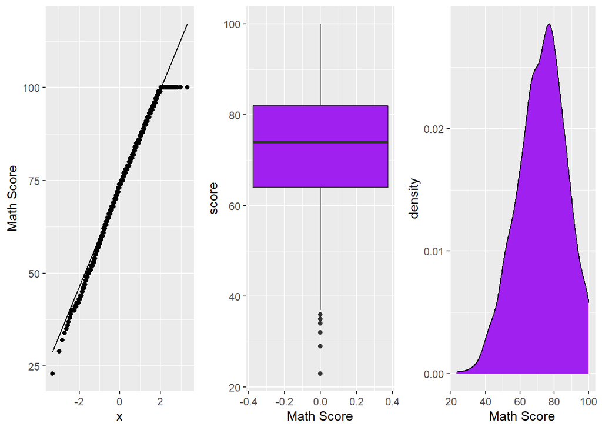

```r
p1 <- ggplot(all_complete, aes(sample = score)) + ylab("Math Score") +
  stat_qq() +
  stat_qq_line()

p2 <- ggplot(all_complete, aes(y = score)) +
  xlab("Math Score")
p2 <- p2 + geom_boxplot(fill=I("purple"))

p3 <- ggplot(all_complete, aes(x = score)) +
  xlab("Math Score")

p3 <- p3 + geom_density(fill=I("purple"))

ggarrange(p1, p2, p3, ncol =3, nrow = 1)
```

```r
shapiro.test(all_complete$score)
```

```
##
##  Shapiro-Wilk normality test
##
## data:  all_complete$score
## W = 0.99019, p-value = 1.378e-06
```

As we can see from plots and also in Shapiro(p<0.05) we can say that our data is not normally distributed, it seems left-sqewed However, let’s try log transformation to see what is going to happen.We’ll have log transformation to get more normally distributed data.

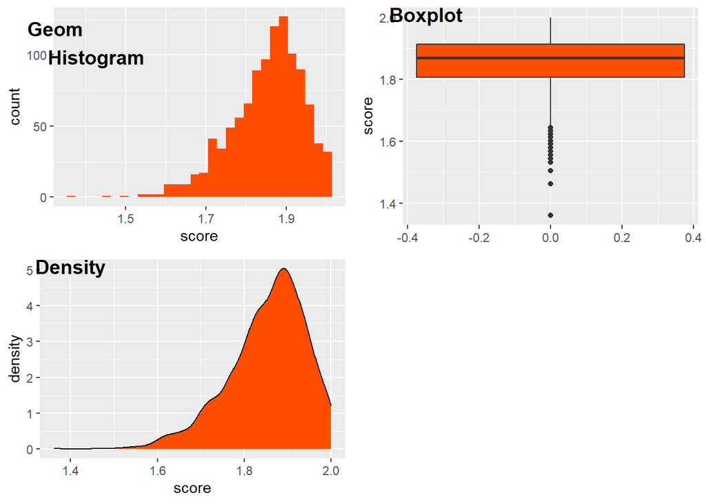

```r
all_complete.transform <- transform(all_complete,
 score = log10(score))

base.plot <- ggplot(all_complete.transform, aes(x =
score)) +
 xlab("score")
p1 <- base.plot + geom_histogram(fill="#ff4d00")
p2 <-ggplot(all_complete.transform, aes(y = score)) +
geom_boxplot(fill="#ff4d00")
p3 <- base.plot + geom_density(fill="#ff4d00")
ggarrange(p1, p2, p3, ncol =2, nrow = 2, labels = c( "Geom
Histogram","Boxplot","Density"))
```

```r
shapiro.test(all_complete.transform$score)
```

```
##
##  Shapiro-Wilk normality test
##
## data:  all_complete.transform$score
## W = 0.95441, p-value < 2.2e-16
```

As we can see from plots and also in Shapiro(p<0.05) then the null hypothesis that the data are normally distributed is rejected. However, it seems that log transformation didn’t work for transform the data to more normally distributed.

From now on we’ll assume that our data is normally distributed

# 7. Single t-test

**b. Hypothesis and level of significance :**

- *H0:* Mu reading.score.bachelor’s.parent >= 70
- *H1:* Mu reading.score.bachelor’s.parent < 70
- *significant level:* 0.05.

**c. Assumption Check :** We’ll assume that we don’t have an information about sample standard deviation and assume that there is no significant difference between variances, and we’ll use t-test.

```r
parental.edu.bachelor <- subset(student_df, subset = student_df$parental_education == "bachelor's degree" )
head(parental.edu.bachelor)
```

```
##    gender race_ethnicity parental_education        lunch test_prep math_score
## 1  female        group B  bachelor's degree     standard      none         72
## 25   male        group D  bachelor's degree free/reduced completed         74
## 28 female        group C  bachelor's degree     standard      none         67
## 61   male        group E  bachelor's degree free/reduced completed         79
## 78   male        group A  bachelor's degree     standard completed         80
## 91 female        group C  bachelor's degree     standard      none         65
##    reading_score writing_score
## 1             72            74
## 25            71            80
## 28            69            75
## 61            74            72
## 78            78            81
## 91            72            74
```

First summarize the reading scores

```r
summary(parental.edu.bachelor$reading_score)
```

```
##    Min. 1st Qu.  Median    Mean 3rd Qu.    Max.
##   41.00   63.00   73.00   73.00   82.75  100.00
```

It seems that mean is greater than 70. Now let’s look at the shape of data.

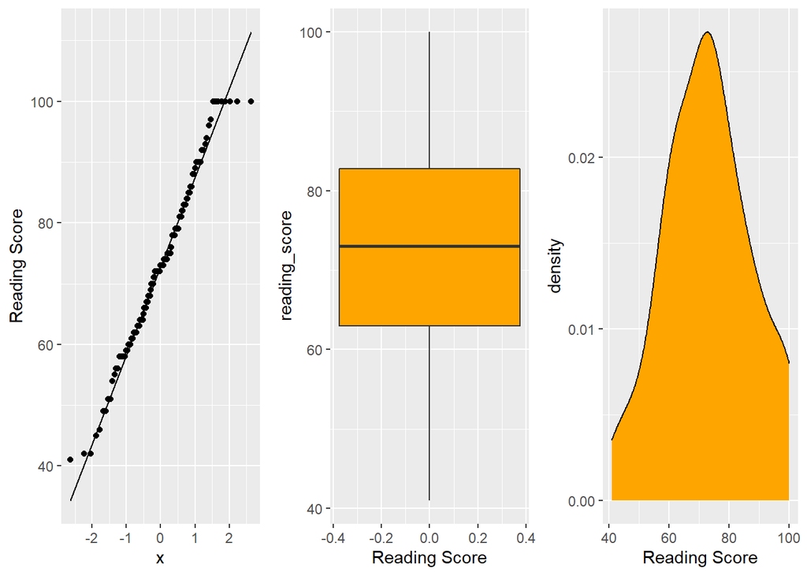

```r
p1 <- ggplot(parental.edu.bachelor, aes(sample = reading_score)) + ylab("Reading Score") +
  stat_qq() +
  stat_qq_line()

p2 <- ggplot(parental.edu.bachelor, aes(y = reading_score)) +
  xlab("Reading Score")
p2 <- p2 + geom_boxplot(fill=I("orange"))

p3 <- ggplot(parental.edu.bachelor, aes(x = reading_score)) +
  xlab("Reading Score")

p3 <- p3 + geom_density(fill=I("orange"))

ggarrange(p1, p2, p3, ncol =3, nrow = 1)
```

```r
shapiro.test(parental.edu.bachelor$reading_score)
```

```
##
##  Shapiro-Wilk normality test
##
## data:  parental.edu.bachelor$reading_score
## W = 0.98225, p-value = 0.1217
```

As we can see from plots and also in Shapiro(p>0.05) we can not reject that our data is normally distributed and we can assume that data is normally distributed.

Now let’s compute the One Sample t-test.

- *H0:* Mu reading.score.bachelor’s.parent >= 70
- *H1:* Mu reading.score.bachelor’s.parent < 70

```r
bachelor.parent.reading.test<- t.test(parental.edu.bachelor$reading_score, alternative = c("less"), mu = 70, conf.level = 0.95)
bachelor.parent.reading.test
```

```
##
##  One Sample t-test
##
## data:  parental.edu.bachelor$reading_score
## t = 2.2813, df = 117, p-value = 0.9878
## alternative hypothesis: true mean is less than 70
## 95 percent confidence interval:
##      -Inf 75.18035
## sample estimates:
## mean of x
##        73
```

**e. Result :** The p-value of the t-Test is: 0.98 which greater than 0.05. Due to its greater than our significance level(0.05) there is not enough evidence to reject the null hypothesis.”

**f. Conclusion :** After computing the t-test we found the p-value > 0.05 which means that the average reading score of students whose parents have a bachelor’s degree is not less than 70.

**g. What can be Type-1 and Type-2 error here :** Type1 Error: Mu reading.score.bachelor’s.parent >= 70 but we rejected the null hypothesis.

Type2 Error: Mu reading.score.bachelor’s.parent < 70 but we fail to reject the null hypothesis.